# English Premier League 19/20 Performance

The data file contains match information from the English premier league during the 19/20 season.

```r
data <- read.csv("football.csv", header = TRUE)
```

There are 892 matches and 21 features of the data.

```r
nrow(data)
```

```
## [1] 892
```

```r
ncol(data)
```

```
## [1] 21
```

Expected Goals, or `xG`, are the number of goals a team should have scored when considering the number and type of chances they had in a match.

The “Score” column contains sometimes invalid scores e.g. “01-Mar”. We can impute these values using GS and GA.

```r
unique(data$Score)
```

```
##  [1] "1-0"    "0-1"    "01-Mar" "3-0"    "0-2"    "0-3"    "01-Feb" "0-0"
##  [9] "01-Jan" "02-Feb" "2-0"    "03-Jan" "02-Jan" "03-Feb" "4-0"    "0-4"
## [17] "02-Mar" "05-Jan" "01-Apr" "01-Jun" "03-Apr" "07-Feb" "02-May" "04-Jan"
## [25] "02-Apr" "03-Mar" "0-5"    "03-May" "04-Feb" "05-Feb" "04-Mar" "9-0"
## [33] "5-0"    "02-Jul" "05-Mar" "06-Jan" "8-0"    "01-May" "0-9"    "0-8"
```

```r
data$Score = paste(data$GS, data$GA, sep = "-")

unique(data$Score)
```

```
##  [1] "1-0" "0-1" "1-3" "3-0" "0-2" "0-3" "1-2" "0-0" "1-1" "2-2" "2-0" "3-1"
## [13] "2-1" "3-2" "4-0" "0-4" "2-3" "5-1" "1-4" "1-6" "3-4" "7-2" "2-5" "4-1"
## [25] "2-4" "3-3" "0-5" "3-5" "4-2" "5-2" "4-3" "9-0" "5-0" "2-7" "5-3" "6-1"
## [37] "8-0" "1-5" "0-9" "0-8"
```

There are 132 rows associated with the 20/21 year. *Should these be removed as our questions of interest are for the 19/20 season only?*

```r
test.data <- data[data$Season == "2020/21",]
training.data <- data[data$Season == "2019/20",]

nrow(data)
```

```
## [1] 892
```

```r
nrow(test.data)
```

```
## [1] 132
```

```r
nrow(training.data)
```

```
## [1] 760
```

The “Date Range” and “League” features are always the same value. We can remove these from the data frame.

```r
unique(data$Date.Range)
```

```
## [1] TRUE
```

```r
unique(data$League)
```

```
## [1] "English Premier League"
```

```r
data <- subset(data, select = -c(Date.Range, League))
```

The available teams are valid.

```r
teams <- unique(data$Team)
awayTeams <- unique(data$AT)
homeTeams <- unique(data$HT)

print(teams)
```

```
##  [1] "Arsenal"          "Aston Villa"      "Bournemouth"      "Brighton"
##  [5] "Burnley"          "Chelsea"          "Crystal Palace"   "Everton"
##  [9] "Fulham"           "Leeds"            "Leicester"        "Liverpool"
## [13] "Man City"         "Man United"       "Newcastle"        "Norwich"
## [17] "Sheffield United" "Southampton"      "Tottenham"        "Watford"
## [21] "West Brom"        "West Ham"         "Wolves"
```

```r
print(sort(teams) == sort(awayTeams) & sort(teams) == sort(homeTeams))
```

```
##  [1] TRUE TRUE TRUE TRUE TRUE TRUE TRUE TRUE TRUE TRUE TRUE TRUE TRUE TRUE TRUE
## [16] TRUE TRUE TRUE TRUE TRUE TRUE TRUE TRUE
```

The format of the dates can be MM/DD/YYYY or M/DD/YYYY.

```r
head(data$Date, n = 3)
```

```
## [1] "11/01/2020" "10/17/2020" "9/28/2020"
```

```r
data$Date <- as.Date(data$Date, format = "%m/%d/%y")

str(data$Date)
```

```
##  Date[1:892], format: "2020-11-01" "2020-10-17" "2020-09-28" "2020-09-12" "2020-07-21" ...
```

The goals scored and conceded values are in the range 0 - 9.

```r
unique(data$GS)
```

```
##  [1] 1 0 3 2 4 5 7 9 6 8
```

```r
unique(data$GA)
```

```
##  [1] 0 1 3 2 4 6 5 7 9 8
```

The points awarded are valid (0, 1, or 3.)

```r
unique(data$Pts)
```

```
## [1] 3 0 1
```

```r
unique(data$xG.Pts)
```

```
## [1] 3 0 1
```

The expected goals are floating point values, but there is no such concept as .1 of a goal.

```r
unique(data$xG)
```

```
##  [1] 1.1 0.8 1.5 3.0 0.9 1.4 0.7 1.9 1.7 1.2 1.8 0.5 2.2 1.0 0.3 1.3 2.1 2.4 0.6
## [20] 2.3 2.9 2.0 0.4 1.6 4.0 3.1 3.2 0.1 0.2 2.5 2.7 2.8 0.0 3.3 3.4 4.4 3.6 4.1
## [39] 3.5 2.6 3.9 4.2 4.3 5.1 3.8 7.1 4.5
```

The lower and upper bound for expected goals is -0.36 and 0.42 respectively.

```r
unique(data$Lower.xG)
```

```
## [1] -0.36
```

```r
unique(data$Upper.xG)
```

```
## [1] 0.42
```

```r
unique(data$Pts.vs.xG..ve)
```

```
## [1]  0  1 NA  2  3
```

```r
unique(data$Pts.vs.xG..ve.1)
```

```
## [1] NA -1 -2 -3
```

```r
data$Pts.vs.xG..ve <- data$Upper.xG - data$Pts
data$Pts.vs.xG..ve.1 <- data$Pts - data$Lower.xG
```

```r
cors <- cor(data[,c("GS", "GA", "Pts", "xG", "xGA", "Net.xG", "xG.Pts")])
print(cors)
```

```
##                GS         GA        Pts         xG        xGA     Net.xG
## GS      1.0000000 -0.1853034  0.6729525  0.6086716 -0.2055551  0.5037359
## GA     -0.1853034  1.0000000 -0.6278554 -0.2055551  0.6086716 -0.5037359
## Pts     0.6729525 -0.6278554  1.0000000  0.4366086 -0.4086836  0.5245152
## xG      0.6086716 -0.2055551  0.4366086  1.0000000 -0.3053209  0.8074337
## xGA    -0.2055551  0.6086716 -0.4086836 -0.3053209  1.0000000 -0.8074337
## Net.xG  0.5037359 -0.5037359  0.5245152  0.8074337 -0.8074337  1.0000000
## xG.Pts  0.4527386 -0.3989289  0.4978525  0.7140536 -0.6368717  0.8363169
##            xG.Pts
## GS      0.4527386
## GA     -0.3989289
## Pts     0.4978525
## xG      0.7140536
## xGA    -0.6368717
## Net.xG  0.8363169
## xG.Pts  1.0000000
```

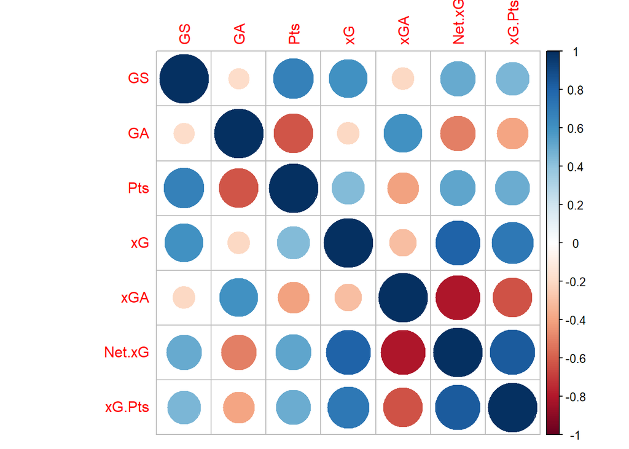

```r
library(corrplot)
corrplot(cors)
```

The correlation between goals scored and expected goals scored is 0.6, but only when you include observations for all teams.

Breaking it down by team we discover that the relationship ranges from strong to weak depending on the team.

```r
team.cors <- data.frame()
for (t in unique(data$Team)) {
  t.data <- subset(data, data$Team == t)
  team.cors <- rbind(team.cors, c(t, cor(t.data$GS, t.data$xG)))
}
colnames(team.cors) <- c("Team", "GS/xG Correlation")
team.cors <- team.cors[order(team.cors$`GS/xG Correlation`, decreasing = TRUE),]
print(team.cors)
```

```
##                Team  GS/xG Correlation
## 23           Wolves   0.79233394889445
## 8           Everton  0.759028963233943
## 9            Fulham  0.752287403410076
## 2       Aston Villa  0.742514539690434
## 11        Leicester  0.710998320574509
## 14       Man United    0.6479033920882
## 3       Bournemouth  0.629075004720108
## 1           Arsenal  0.601275388219331
## 13         Man City  0.592763578007596
## 22         West Ham  0.591364260206577
## 20          Watford  0.576653859410519
## 19        Tottenham   0.57337039825092
## 7    Crystal Palace  0.563638891494652
## 15        Newcastle  0.482089297840058
## 5           Burnley  0.472744004859721
## 17 Sheffield United  0.450286621024052
## 21        West Brom  0.387298334620742
## 12        Liverpool  0.386197420693542
## 18      Southampton  0.343113070125738
## 4          Brighton  0.339449573624474
## 16          Norwich  0.323820782832628
## 6           Chelsea   0.24920139362506
## 10            Leeds -0.160664598034026
```